# Appendix D. EVMP Willow Statistical Analyses

### Contrasts

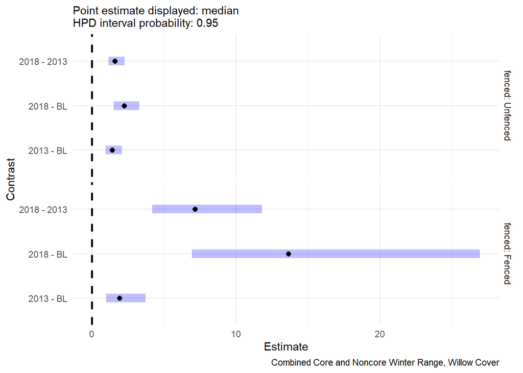

```r
# contrast - time class and fencing
emmeans(stmod_cov.wc.wnc, ~ time_class | fenced) %>%
  pairs(reverse=TRUE) %>%
  # plot() + # Results are given on the logit (not the response) scale.
  plot(type = "response") +
  theme_minimal() +
  geom_vline(aes(xintercept = 0), color= "black", size=1, lty="dashed") +
  labs(subtitle = "Point estimate displayed: median
HPD interval probability: 0.95", x = "Estimate", y = "Contrast", caption = "Combined Core and Noncore Winter Range, Willow Cover")
```

```r
ggsave("./output/figures_202107/willow_cover/emm_willowht_TCxF_wcwnc.png", width = 6.75, height =3.75, dpi = 300)
# ggsave("./output/figures_202107/willow_cover/emm_willowht_TCxF_wcwnc.pdf", width = 6.75, height =3.75)


# table of contrasts
emmeans(stmod_cov.wc.wnc, ~ time_class | fenced) %>%
  pairs(reverse = TRUE) %>%
  as_tibble() %>%
  mutate(across(where(is.numeric),round, 2)) %>%
  gt() %>%
  tab_header(title = "Pairwise contrasts", subtitle = "Results are given on the log odds ratio, not the response scale")
```

Pairwise contrasts

Results are given on the log odds ratio, not the response scale

| contrast | fenced | estimate | lower.HPD | upper.HPD |
| --- | --- | --- | --- | --- |
| 2013 - BL | Unfenced | 0.34 | -0.07 | 0.73 |
| 2018 - BL | Unfenced | 0.80 | 0.40 | 1.19 |
| 2018 - 2013 | Unfenced | 0.47 | 0.13 | 0.82 |
| 2013 - BL | Fenced | 0.64 | 0.00 | 1.32 |
| 2018 - BL | Fenced | 2.61 | 1.94 | 3.29 |
| 2018 - 2013 | Fenced | 1.97 | 1.43 | 2.47 |

```r
emmeans(stmod_cov.wc.wnc, ~ time_class | fenced) %>%
  pairs(reverse = TRUE, type="response") %>%
  as_tibble() %>%
  mutate(across(where(is.numeric),round, 2)) %>%
  gt() %>%
  tab_header(title = "Pairwise contrasts", subtitle = "Results are given on the response scale")
```

Pairwise contrasts

Results are given on the response scale

| contrast | fenced | odds.ratio | lower.HPD | upper.HPD |
| --- | --- | --- | --- | --- |
| 2013 / BL | Unfenced | 1.40 | 0.89 | 2.02 |
| 2018 / BL | Unfenced | 2.23 | 1.40 | 3.18 |
| 2018 / 2013 | Unfenced | 1.60 | 1.09 | 2.19 |
| 2013 / BL | Fenced | 1.90 | 0.88 | 3.47 |
| 2018 / BL | Fenced | 13.64 | 5.87 | 24.59 |
| 2018 / 2013 | Fenced | 7.17 | 3.79 | 11.32 |

```r
# bayesplot::mcmc_areas(posteriors.cov.wcwnc,
#            pars = c("time_class2013", "time_class2018", "time_class2013:fencedFenced","time_class2018:fencedFenced"),
#            prob = 0.9) +
#   theme_minimal() +
#   labs(title = "Posterior distributions", subtitle = "with medians and 90% intervals", caption = "Willow height, WC & WNC")
#
# ggsave("./output/figures_202107/willow_cover/mcmcarea_willowcov_TCxF_wcwnc.png", dpi = 300, width = 6.75, height = 3.75)
# ggsave("./output/figures_202107/willow_cover/mcmcarea_willowcov_TCxF_wcwnc.pdf", width = 6.75, height = 3.75)
```

### Effects of Burning - Combined Range

```r
#### Fenced and burned

stmod_cov.wc.wnc.TCxFxB <- stan_glmer(cover_allwillow ~ time_class * burned * fenced + (1 | site_id),
                      data = cov.wc.wnc,
                      family = mgcv::betar,
                      prior_aux = exponential(1),
                      iter = 8000,
                      seed = 1234)
```

**Prior summary** cover_allwillow ~ time_class * burned * fenced + (1 | site_id)

```r
prior_summary(stmod_cov.wc.wnc.TCxFxB)
```

```
## Priors for model 'stmod_cov.wc.wnc.TCxFxB'
## ------
## Intercept (after predictors centered)
##  ~ normal(location = 0, scale = 2.5)
##
## Coefficients
##   Specified prior:
##     ~ normal(location = [0,0,0,...], scale = [2.5,2.5,2.5,...])
##   Adjusted prior:
##     ~ normal(location = [0,0,0,...], scale = [5.22,5.15,6.19,...])
##
## Covariance
##  ~ decov(reg. = 1, conc. = 1, shape = 1, scale = 1)
## ------
## See help('prior_summary.stanreg') for more details
```

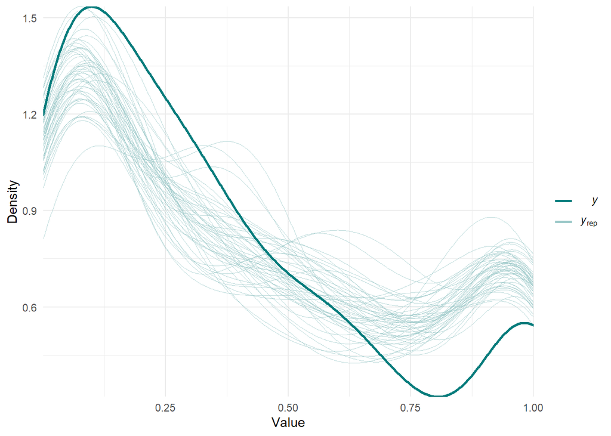

```r
pp_check(stmod_cov.wc.wnc.TCxFxB) +
  labs(x = "Value", y = "Density") +
  theme_minimal()
```

```r
#
ggsave("./output/figures_202107/wc_wnc_willowcover_ppc_TCxFxB.png", dpi = 300, width = 4.75, height = 3.75)
```

```r
## extract posterior
posteriors.cov.wcwnc.TCxFxB <- insight::get_parameters(stmod_cov.wc.wnc.TCxFxB)
```

### Effect Description

```r
fun.sexit.gt(stmod_cov.wc.wnc.TCxFxB$stanfit)
```

Effect Existence and Significance Testing

| Parameter | Median | CI | CI_low | CI_high | Direction | Significance | Large |
| --- | --- | --- | --- | --- | --- | --- | --- |
| (Intercept) | -0.60 | 0.9 | -1.04 | -0.16 | 0.99 | 0.98 | 0.86 |
| time_class2013 | 0.39 | 0.9 | 0.06 | 0.73 | 0.97 | 0.95 | 0.67 |
| time_class2018 | 0.86 | 0.9 | 0.53 | 1.19 | 1.00 | 1.00 | 1.00 |
| burnedBurned | -0.91 | 0.9 | -3.29 | 1.53 | 0.74 | 0.73 | 0.66 |
| fencedFenced | -0.45 | 0.9 | -1.49 | 0.55 | 0.76 | 0.74 | 0.60 |
| time_class2013:burnedBurned | -1.16 | 0.9 | -3.39 | 1.42 | 0.78 | 0.77 | 0.72 |
| time_class2018:burnedBurned | -1.05 | 0.9 | -3.25 | 1.33 | 0.77 | 0.76 | 0.71 |
| time_class2013:fencedFenced | 0.41 | 0.9 | -0.35 | 1.17 | 0.81 | 0.78 | 0.59 |
| time_class2018:fencedFenced | 2.16 | 0.9 | 1.41 | 2.97 | 1.00 | 1.00 | 1.00 |
| burnedBurned:fencedFenced | -0.39 | 0.9 | -3.11 | 2.40 | 0.60 | 0.58 | 0.52 |
| time_class2013:burnedBurned:fencedFenced | 0.70 | 0.9 | -2.05 | 3.20 | 0.67 | 0.65 | 0.59 |
| time_class2018:burnedBurned:fencedFenced | 0.12 | 0.9 | -2.43 | 2.56 | 0.53 | 0.52 | 0.45 |
| (phi) | 4.67 | 0.9 | 3.70 | 5.67 | 1.00 | 1.00 | 1.00 |
| mean_PPD | 0.41 | 0.9 | 0.39 | 0.44 | 1.00 | 1.00 | 1.00 |
| log-posterior | 240.22 | 0.9 | 220.59 | 258.80 | 1.00 | 1.00 | 1.00 |

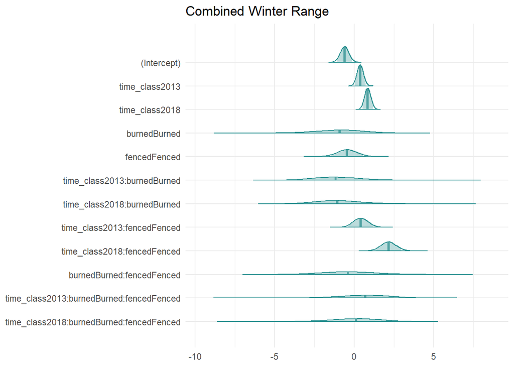

```r
color_scheme_set("teal")
# color_scheme_set("teal")

plot.mcmcareas_cov.wcwnc.TCxFxB <- mcmc_areas(posteriors.cov.wcwnc.TCxFxB,
           prob = 0.9) +
  ggtitle("Combined Winter Range") +
  theme_minimal() +
  theme(text = element_text(family = 'sans'))

plot.mcmcareas_cov.wcwnc.TCxFxB
```

```r
ggsave("./output/figures_202107/willow_cover/mcmcarea_willowcov_wcwnc_TCxFxB.png", dpi = 300, width = 6.75, height = 3.75)
```

## Willow Cover - Core Winter Range Macroplot Data

### Summary Tables

```r
#### summary tables: time class and burned
cov.wc %>%
  group_by(time_class) %>%
  summarytools::descr(cover_allwillow,stats = "common") %>%
  summarytools::tb() %>%
  mutate_if(.predicate = is.numeric,.funs = round, digits = 2) %>%
  gt() %>%
  tab_header(title = "WC macroplot data: willow cover ~ WC: all willow cover - time_class")
```

WC macroplot data: willow cover ~ WC: all willow cover - time_class

| time_class | variable | mean | sd | min | med | max | n.valid | pct.valid |
| --- | --- | --- | --- | --- | --- | --- | --- | --- |
| BL | cover_allwillow | 0.22 | 0.24 | 0 | 0.18 | 1 | 36 | 100 |
| 2013 | cover_allwillow | 0.24 | 0.27 | 0 | 0.14 | 1 | 61 | 100 |
| 2018 | cover_allwillow | 0.44 | 0.35 | 0 | 0.33 | 1 | 62 | 100 |

```r
## time class, fenced and burned
cov.wc %>%
  group_by(time_class, burned) %>%
  summarytools::descr(cover_allwillow, stats = "common") %>%
  summarytools::tb() %>%
  mutate_if(.predicate = is.numeric,.funs = round, digits = 2) %>%
  gt() %>%
  tab_header(title = "WC macroplot data: All willow cover - burned + time_class")
```

WC macroplot data: All willow cover - burned + time_class

| time_class | burned | variable | mean | sd | min | med | max | n.valid | pct.valid |
| --- | --- | --- | --- | --- | --- | --- | --- | --- | --- |
| BL | Unburned | cover_allwillow | 0.28 | 0.24 | 0 | 0.22 | 1.00 | 28 | 100 |
| BL | Burned | cover_allwillow | 0.03 | 0.03 | 0 | 0.02 | 0.09 | 8 | 100 |
| 2013 | Unburned | cover_allwillow | 0.31 | 0.27 | 0 | 0.27 | 1.00 | 39 | 100 |
| 2013 | Burned | cover_allwillow | 0.12 | 0.22 | 0 | 0.03 | 0.79 | 22 | 100 |
| 2018 | Unburned | cover_allwillow | 0.51 | 0.35 | 0 | 0.46 | 1.00 | 41 | 100 |
| 2018 | Burned | cover_allwillow | 0.30 | 0.33 | 0 | 0.20 | 1.00 | 21 | 100 |

### Modeling and Posterior Description

```r
#### Model
## add to min and subtract from max to conform
cov.wc <- cov.wc %>%
  mutate(cover_allwillow = case_when(cover_allwillow == 1 ~ 0.999999,
                                     TRUE ~ cover_allwillow))


stmod_cov.wc <- stan_glmer(cover_allwillow ~ time_class * fenced + (1 | site_id),
                      data = cov.wc,
                      family = mgcv::betar,
                      prior_aux = exponential(2),
                      iter = 8000,
                      seed = 1234)
```

**Prior summary**: cover_allwillow ~ time_class * fenced + (1 | site_id)

```r
prior_summary(stmod_cov.wc)
```

```
## Priors for model 'stmod_cov.wc'
## ------
## Intercept (after predictors centered)
##  ~ normal(location = 0, scale = 2.5)
##
## Coefficients
##   Specified prior:
##     ~ normal(location = [0,0,0,...], scale = [2.5,2.5,2.5,...])
##   Adjusted prior:
##     ~ normal(location = [0,0,0,...], scale = [5.12,5.11,5.00,...])
##
## Covariance
##  ~ decov(reg. = 1, conc. = 1, shape = 1, scale = 1)
## ------
## See help('prior_summary.stanreg') for more details
```

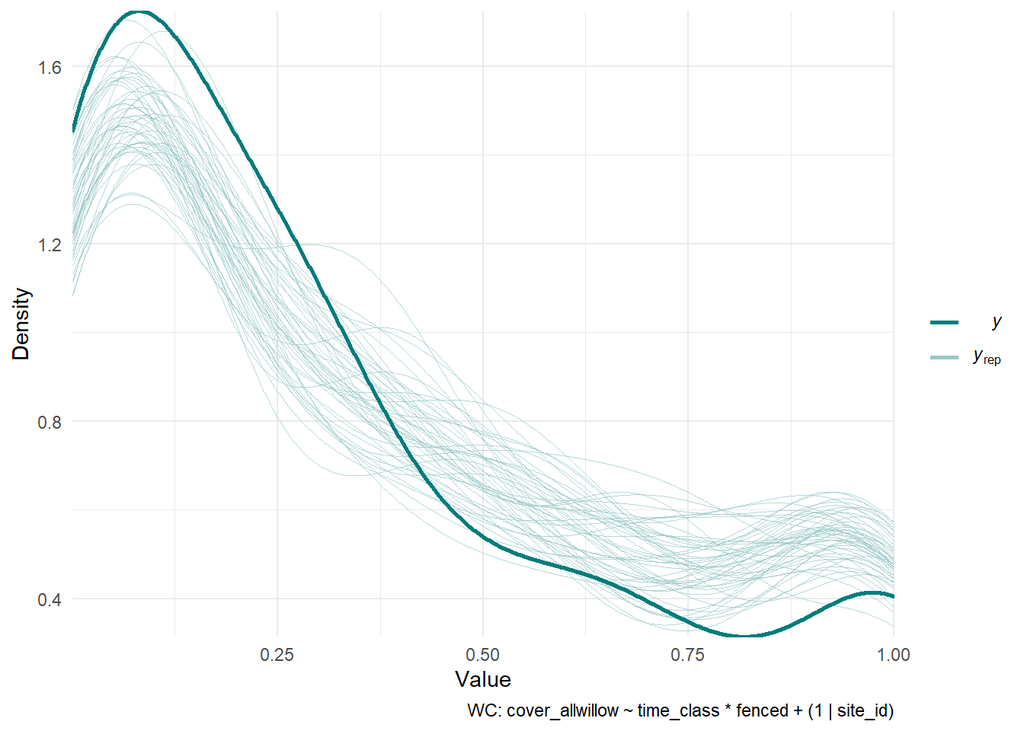

```r
#### PP check plot
pp_check(stmod_cov.wc) +
  labs(x = "Value", y = "Density") +
  theme_minimal() +
  labs(caption = "WC: cover_allwillow ~ time_class * fenced + (1 | site_id)")
```

```r
ggsave("./output/figures_202107/willow_cover/ppc_willowcov_wc.png", dpi = 300, width = 4.75, height = 3.75)
# ggsave("./output/figures_202107/willow_cover/ppc_willowcov_wc.pdf", width = 4.75, height = 3.75)
```

### Effect Description

```r
fun.sexit.gt(stmod_cov.wc$stanfit)
```

Effect Existence and Significance Testing

| Parameter | Median | CI | CI_low | CI_high | Direction | Significance | Large |
| --- | --- | --- | --- | --- | --- | --- | --- |
| (Intercept) | -1.29 | 0.9 | -1.88 | -0.66 | 1.00 | 1.00 | 1.00 |
| time_class2013 | 0.10 | 0.9 | -0.37 | 0.58 | 0.64 | 0.57 | 0.25 |
| time_class2018 | 0.49 | 0.9 | 0.03 | 0.93 | 0.96 | 0.95 | 0.75 |
| fencedFenced | -0.52 | 0.9 | -1.44 | 0.44 | 0.82 | 0.80 | 0.65 |
| time_class2013:fencedFenced | 0.60 | 0.9 | -0.11 | 1.33 | 0.91 | 0.89 | 0.76 |
| time_class2018:fencedFenced | 2.25 | 0.9 | 1.56 | 2.98 | 1.00 | 1.00 | 1.00 |
| (phi) | 5.34 | 0.9 | 3.92 | 6.86 | 1.00 | 1.00 | 1.00 |
| mean_PPD | 0.35 | 0.9 | 0.33 | 0.38 | 1.00 | 1.00 | 1.00 |
| log-posterior | 150.75 | 0.9 | 133.58 | 165.79 | 1.00 | 1.00 | 1.00 |

```r
fun.sexit.gt(stmod_cov.wc$stanfit) %>%
  tab_header(title = "Core Winter Range", subtitle = "Willow Cover Posterior Description") %>%
  gt::gtsave(filename = "./output/tables/willow_cover/posterior_willowht_wc.rtf")
```

#### Probability of Direction

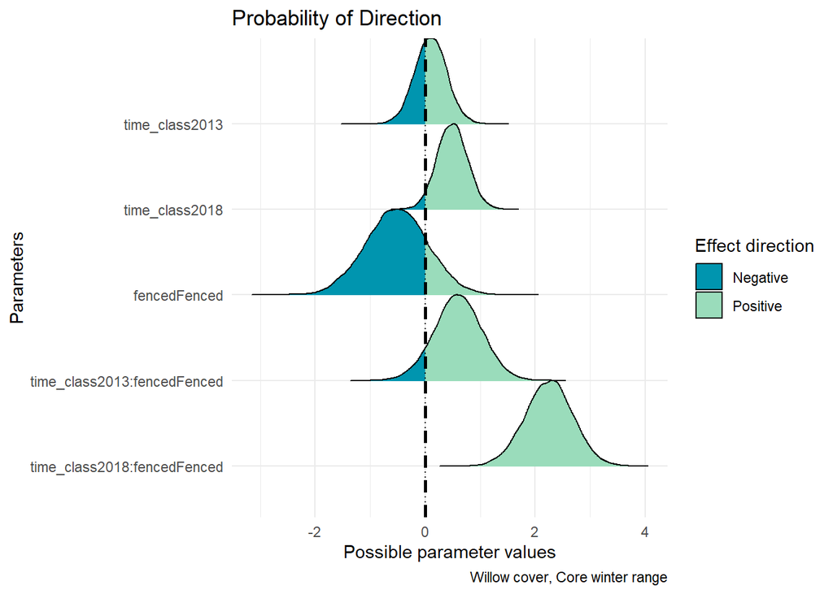

```r
# Visualize the pd
p_direction(stmod_cov.wc) %>%
  plot() +
  theme_minimal() +
  geom_vline(aes(xintercept = 0), color= "black", size=1, lty="dashed") +
  labs(caption = "Willow cover, Core winter range") +
  scale_fill_manual(values = colfunc3(2))
```

```r
ggsave("./output/figures_202107/willow_cover/pd_willowht_wc.png", width = 6.75, height =3.75, dpi = 300)
# ggsave("./output/figures_202107/willow_cover/pd_willowht_wc.pdf", width = 6.75, height =3.75)
```

#### Region of Practical Equivalence (ROPE)

```r
rope.cov.wc.gt <- rope(stmod_cov.wc$stanfit, ci=0.9) %>%
  gt() %>%
  tab_header(title = "Percent in ROPE") %>%
  fmt_number(
    columns = 5,
    decimals = 2,
    suffixing = TRUE
  )

rope.cov.wcwnc.gt %>%
  gt::gtsave(filename = "./output/tables/willow_cover/rope_willowcov_wc.rtf")
```

### Contrasts

Results are given on the the response scale.

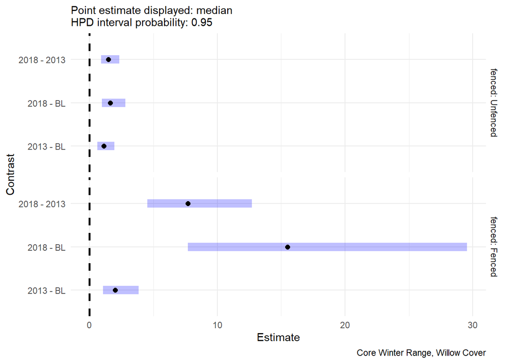

```r
# library(emmeans)
wc.cov.emm.TCxF <- emmeans(stmod_cov.wc, ~ time_class | fenced)

pairs(wc.cov.emm.TCxF, reverse = TRUE, type="response") %>%
  plot() +
  theme_minimal() +
  geom_vline(aes(xintercept = 0), color= "black", size=1, lty="dashed") +
  labs(subtitle = "Point estimate displayed: median
HPD interval probability: 0.95", x = "Estimate", y = "Contrast", caption = "Core Winter Range, Willow Cover")
```

```r
ggsave("./output/figures_202107/willow_cover/emm_willowht_TCxF_wc.png", width = 6.75, height =3.75, dpi = 300)
# ggsave("./output/figures_202107/willow_cover/emm_willowht_TCxF_wc.pdf", width = 6.75, height =3.75)

# table of contrasts
emmeans(stmod_cov.wc, ~ time_class | fenced) %>%
  pairs(reverse = TRUE) %>%
  as_tibble() %>%
  mutate(across(where(is.numeric),round, 2)) %>%
  gt() %>%
  tab_header(title = "Pairwise contrasts", subtitle = "Results are given on the log odds ratio, not the response scale")
```

Pairwise contrasts

Results are given on the log odds ratio, not the response scale

| contrast | fenced | estimate | lower.HPD | upper.HPD |
| --- | --- | --- | --- | --- |
| 2013 - BL | Unfenced | 0.10 | -0.47 | 0.67 |
| 2018 - BL | Unfenced | 0.49 | -0.05 | 1.04 |
| 2018 - 2013 | Unfenced | 0.39 | -0.08 | 0.84 |
| 2013 - BL | Fenced | 0.70 | 0.04 | 1.35 |
| 2018 - BL | Fenced | 2.74 | 2.04 | 3.39 |
| 2018 - 2013 | Fenced | 2.04 | 1.51 | 2.54 |

```r
emmeans(stmod_cov.wc, ~ time_class | fenced) %>%
  pairs(reverse = TRUE, type="response") %>%
  as_tibble() %>%
  mutate(across(where(is.numeric),round, 2)) %>%
  gt() %>%
  tab_header(title = "Pairwise contrasts", subtitle = "Results are given on the response scale")
```

Pairwise contrasts

Results are given on the response scale

| contrast | fenced | odds.ratio | lower.HPD | upper.HPD |
| --- | --- | --- | --- | --- |
| 2013 / BL | Unfenced | 1.11 | 0.56 | 1.83 |
| 2018 / BL | Unfenced | 1.63 | 0.89 | 2.66 |
| 2018 / 2013 | Unfenced | 1.47 | 0.87 | 2.25 |
| 2013 / BL | Fenced | 2.01 | 0.89 | 3.56 |
| 2018 / BL | Fenced | 15.48 | 6.34 | 27.48 |
| 2018 / 2013 | Fenced | 7.70 | 4.31 | 12.35 |

## Willow Cover - Noncore Winter Range Macroplot Data

```r
#### summary tables: time class and fenced
cov.wnc %>%
  group_by(time_class, fenced) %>%
  summarytools::descr(cover_allwillow,stats = "common") %>%
  summarytools::tb() %>%
  mutate_if(.predicate = is.numeric,.funs = round, digits = 2) %>%
  gt() %>%
  tab_header(title = "WNC macroplot data: willow cover")
```

WNC macroplot data: willow cover

| time_class | fenced | variable | mean | sd | min | med | max | n.valid | pct.valid |
| --- | --- | --- | --- | --- | --- | --- | --- | --- | --- |
| BL | Unfenced | cover_allwillow | 0.37 | 0.28 | 0.03 | 0.32 | 1 | 32 | 100 |
| 2013 | Unfenced | cover_allwillow | 0.43 | 0.32 | 0.02 | 0.37 | 1 | 27 | 100 |
| 2018 | Unfenced | cover_allwillow | 0.56 | 0.33 | 0.01 | 0.53 | 1 | 32 | 100 |

### Modeling and Posterior Description

```r
#### Model
## add to min and subtract from max to conform
cov.wnc <- cov.wnc %>%
  mutate(cover_allwillow = case_when(cover_allwillow == 1 ~ 0.999999,
                                     TRUE ~ cover_allwillow))

stmod_cov.wnc <- stan_glmer(cover_allwillow ~ time_class + (1 | site_id),
                      data = cov.wnc,
                      family = mgcv::betar,
                      # prior_aux = exponential(2),
                      iter = 10000,
                      seed = 1234)
```

**Prior summary**: cover_allwillow ~ time_class + (1 | site_id)

```r
prior_summary(stmod_cov.wnc)
```

```
## Priors for model 'stmod_cov.wnc'
## ------
## Intercept (after predictors centered)
##  ~ normal(location = 0, scale = 2.5)
##
## Coefficients
##   Specified prior:
##     ~ normal(location = [0,0], scale = [2.5,2.5])
##   Adjusted prior:
##     ~ normal(location = [0,0], scale = [5.44,5.21])
##
## Covariance
##  ~ decov(reg. = 1, conc. = 1, shape = 1, scale = 1)
## ------
## See help('prior_summary.stanreg') for more details
```

### Effect Description

```r
fun.sexit.gt(stmod_cov.wnc$stanfit)
```

Effect Existence and Significance Testing

| Parameter | Median | CI | CI_low | CI_high | Direction | Significance | Large |
| --- | --- | --- | --- | --- | --- | --- | --- |
| (Intercept) | -0.22 | 0.9 | -0.86 | 0.35 | 0.73 | 0.68 | 0.41 |
| time_class2013 | 0.53 | 0.9 | 0.07 | 1.04 | 0.97 | 0.95 | 0.79 |
| time_class2018 | 1.02 | 0.9 | 0.55 | 1.50 | 1.00 | 1.00 | 0.99 |
| (phi) | 3.03 | 0.9 | 2.11 | 4.00 | 1.00 | 1.00 | 1.00 |
| mean_PPD | 0.52 | 0.9 | 0.47 | 0.57 | 1.00 | 1.00 | 1.00 |
| log-posterior | 81.96 | 0.9 | 70.88 | 92.27 | 1.00 | 1.00 | 1.00 |

```r
fun.sexit.gt(stmod_cov.wnc$stanfit) %>%
  tab_header(title = "Noncore Winter Range", subtitle = "Willow Cover Posterior Description") %>%
  gt::gtsave(filename = "./output/tables/willow_cover/xposterior_willowht_wnc.rtf")
```

#### Probability of Direction

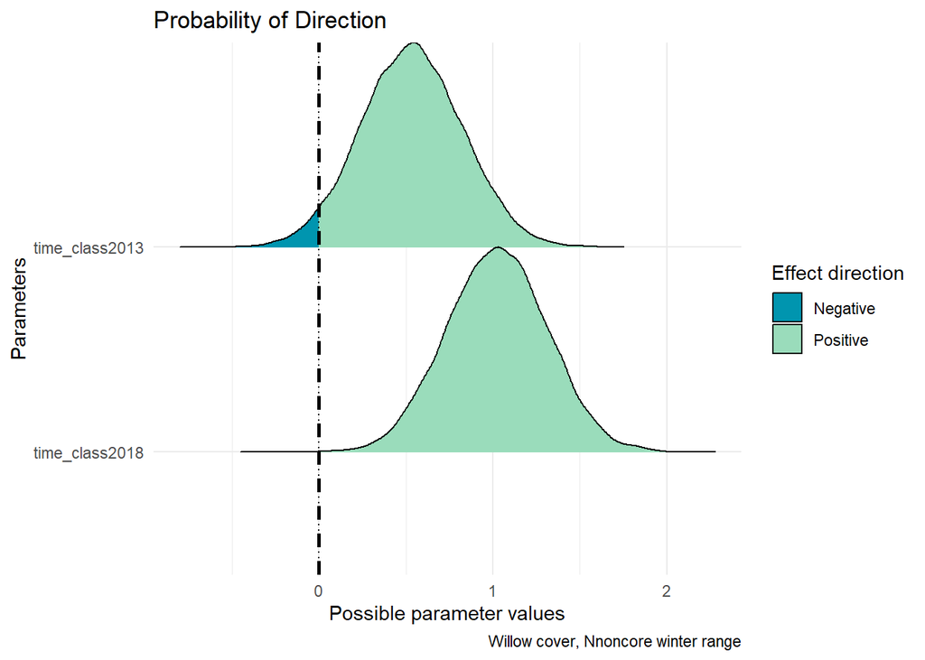

```r
# Visualize the pd
p_direction(stmod_cov.wnc) %>%
  plot() +
  theme_minimal() +
  geom_vline(aes(xintercept = 0), color= "black", size=1, lty="dashed") +
  labs(caption = "Willow cover, Nnoncore winter range") +
  scale_fill_manual(values = colfunc3(2))
```

```r
ggsave("./output/figures_202107/willow_cover/pd_willowht_wnc.png", width = 6.75, height =3.75, dpi = 300)
# ggsave("./output/figures_202107/willow_cover/pd_willowht_wnc.pdf", width = 6.75, height =3.75)
```

#### Region of Practical Equivalence (ROPE)

```r
rope.cov.wnc.gt <- rope(stmod_cov.wnc$stanfit, ci=0.9) %>%
  gt() %>%
  tab_header(title = "Percent in ROPE") %>%
  fmt_number(
    columns = 5,
    decimals = 2,
    suffixing = TRUE
  )

rope.cov.wnc.gt %>%
  gt::gtsave(filename = "./output/tables/willow_cover/rope_willowcov_wnc.rtf")
```

### Contrasts

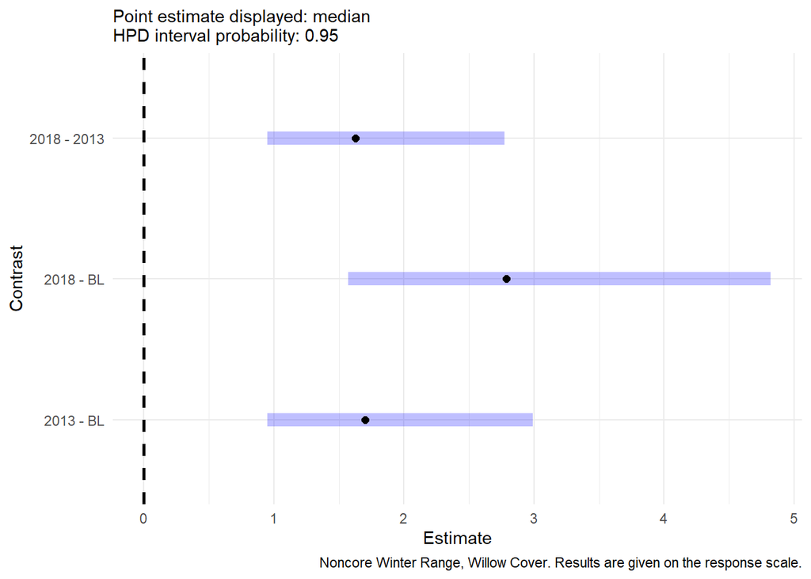

```r
# library(emmeans)
wnc.cov.emm.TC <- emmeans(stmod_cov.wnc, ~ time_class)

pairs(wnc.cov.emm.TC, reverse = TRUE, type="response") %>%
  plot() +
  theme_minimal() +
  geom_vline(aes(xintercept = 0), color= "black", size=1, lty="dashed") +
  labs(subtitle = "Point estimate displayed: median
HPD interval probability: 0.95", x = "Estimate", y = "Contrast", caption = "Noncore Winter Range, Willow Cover. Results are given on the response scale.")
```

```r
# ggsave("./output/figures_202107/willow_cover/emm_willowht_TCxF_wnc.png", width = 6.75, height =3.75, dpi = 300)

# table of contrasts
emmeans(stmod_cov.wnc, ~ time_class) %>%
  pairs(reverse = TRUE) %>%
  as_tibble() %>%
  mutate(across(where(is.numeric),round, 2)) %>%
  gt() %>%
  tab_header(title = "Pairwise contrasts", subtitle = "Results are given on the log odds ratio, not the response scale")
```

Pairwise contrasts

Results are given on the log odds ratio, not the response scale

| contrast | estimate | lower.HPD | upper.HPD |
| --- | --- | --- | --- |
| 2013 - BL | 0.53 | -0.05 | 1.10 |
| 2018 - BL | 1.02 | 0.45 | 1.57 |
| 2018 - 2013 | 0.49 | -0.05 | 1.02 |

```r
emmeans(stmod_cov.wnc, ~ time_class) %>%
  pairs(reverse = TRUE, type="response") %>%
  as_tibble() %>%
  mutate(across(where(is.numeric),round, 2)) %>%
  gt() %>%
  tab_header(title = "Pairwise contrasts", subtitle = "Results are given on the response scale")
```

Pairwise contrasts

Results are given on the response scale

| contrast | odds.ratio | lower.HPD | upper.HPD |
| --- | --- | --- | --- |
| 2013 / BL | 1.70 | 0.85 | 2.83 |
| 2018 / BL | 2.79 | 1.41 | 4.59 |
| 2018 / 2013 | 1.63 | 0.88 | 2.66 |

## Wild Basin Comparisons

```r
# read in data and preprocess for joining with EVMP data
wbasin <- read_csv("./data/wild_basin/Wild Basin willow data survey 2018.csv")

wbasin <- wbasin %>%
  janitor::clean_names()

wbasin.sel <- wbasin %>%
  rename(plant_ht_cm = max_ht_cm) %>%
  mutate(yr = 2018) %>%
  mutate(fenced = "N") %>%
  mutate(site_type = "WB") %>%
  mutate(site_id = paste0("WB",point)) %>%
  dplyr::select(c(yr, site_type, site_id, plant_ht_cm, species, fenced, location)) %>%
  distinct()
```

```r
## process the evmp into a bindable format with wb data
willow.mcro.evmp <- willow.ht %>%
  rename(species = species_code) %>%
  dplyr::select(yr, site_type, species, site_id, plant_ht_cm, fenced, location) %>%
  distinct() %>%
  filter(yr == 2018)

#### bind wb with 2018 evmp
wb.evmp18 <- bind_rows(wbasin.sel, willow.mcro.evmp) %>%
  distinct()
```

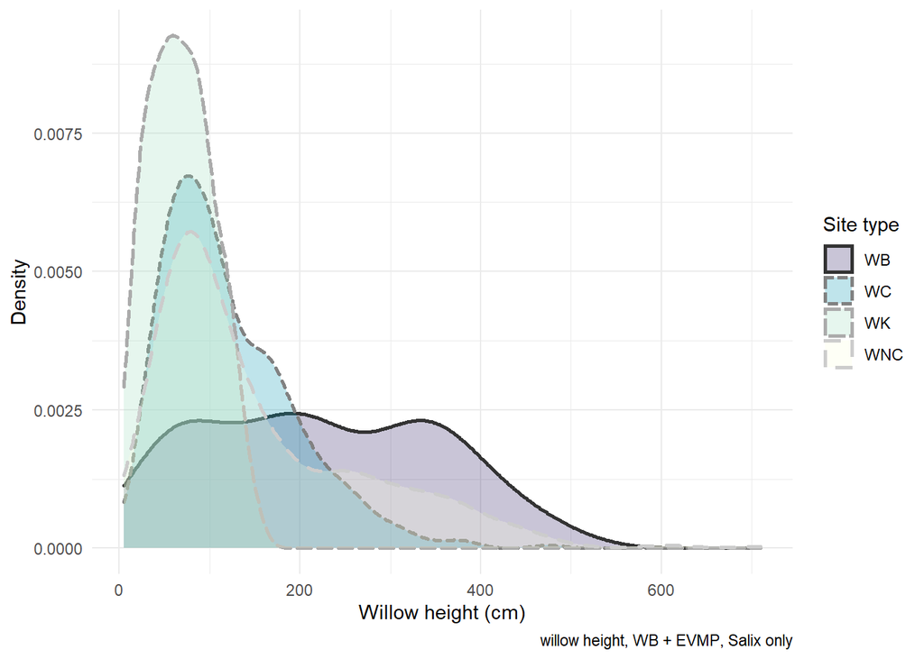

```r
### Willow height comparison among Wild Basin and EVMP plots
## compare WILLOW height

wb.evmp18 %>%
  filter(str_detect(species, "^S")) %>%
  ggplot() +
  geom_density(aes(fill = site_type, color = site_type, lty = site_type, x = plant_ht_cm), size=1, alpha = .25) +
  theme_minimal() +
  scale_fill_manual(values = colfunc1(4)) +
  scale_color_grey() +
  # scale_fill_manual(values = colfunc3_RdBu(4)) +
  # scale_color_manual(values = colfunc3_RdBu(4)) +
  labs(x = "Willow height (cm)", y  = "Density", lty= "Site type", color = "Site type", fill = "Site type", caption = "willow height, WB + EVMP, Salix only")
```

```r
ggsave("./output/figures_202107/WB_EVMP_willow_height.png", dpi = 300, width = 4.75, height = 3.75)
```

```r
wb.evmp18 <- wb.evmp18 %>%
  mutate(site_type.lbl = case_when(site_type == "WB" ~ "Wild Basin",
                               site_type == "WC" ~ "Core winter range",
                               site_type == "WNC" ~ "Noncore winter range",
                               site_type == "WK" ~ "Kawuneeche Valley",
                               TRUE ~ "other")) %>%
  mutate(fenced = case_when(fenced == "N" ~ "Unfenced",
                            fenced == "Y" ~ "Fenced",
                            TRUE ~ fenced)) %>%
  mutate(site.type.fenced = paste0(site_type.lbl,"\n",fenced))

# wb.evmp18 %>% distinct(site.type.fenced)
wb.evmp18.willows <- wb.evmp18 %>%
  filter(str_detect(species, "^S"))
```

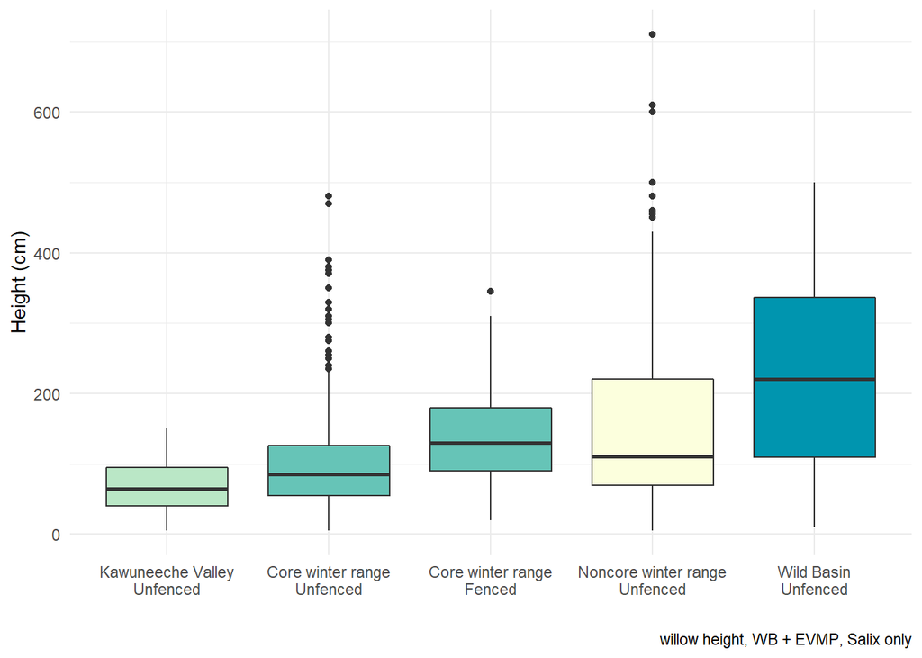

```r
wb.evmp18 %>%
  filter(str_detect(species, "^S")) %>%
  ggplot(aes(x=reorder(site.type.fenced, plant_ht_cm), plant_ht_cm)) +
  geom_boxplot(aes(fill=site_type)) +
  # geom_density(aes(fill = site_type, color = site_type, lty = site_type, x = plant_ht_cm), alpha = 0.05) +
  theme_minimal() +
  scale_fill_manual(values = colfunc2(4)) +
  scale_color_manual(values = colfunc2(4)) +
  theme(legend.position = "none") +
  # theme(axis.text.x = element_text(angle = 0, hjust = 1)) +
  labs(x = "", y  = "Height (cm)", lty= "Site type", color = "Site type", fill = "Site type", caption = "willow height, WB + EVMP, Salix only")
```

```r
ggsave("./output/figures_202107/WB_EVMP_willow_height_boxplot.png", dpi = 300, width = 6.75, height = 4.75)
```

```r
wb.evmp18 %>%
  group_by(site.type.fenced) %>%
  descr(plant_ht_cm, stat="common") %>%
  tb() %>%
  mutate(across(where(is.numeric), round, 1)) %>%
  arrange(-mean) %>%
  datatable(caption = "All willow species combined")
```

|  | site.type.fenced | variable | mean | sd | min | med | max | n.valid | pct.valid |
| --- | --- | --- | --- | --- | --- | --- | --- | --- | --- |
| 1 | Wild Basin Unfenced | plant_ht_cm | 237.7 | 221.1 | 0 | 197.5 | 2000 | 134 | 100 |
| 2 | Noncore winter range Unfenced | plant_ht_cm | 153.2 | 115.6 | 5 | 110 | 710 | 485 | 100 |
| 3 | Core winter range Fenced | plant_ht_cm | 140.3 | 64.3 | 20 | 130 | 345 | 379 | 100 |
| 4 | Core winter range Unfenced | plant_ht_cm | 104.4 | 75.5 | 5 | 85 | 480 | 431 | 100 |
| 5 | Kawuneeche Valley Unfenced | plant_ht_cm | 68.5 | 35.3 | 5 | 65 | 150 | 146 | 100 |

```r
wb.evmp18 %>%
  group_by(site.type.fenced, species) %>%
  descr(plant_ht_cm) %>%
  tb() %>%
  mutate(across(where(is.numeric), round, 1)) %>%
  arrange(-mean) %>%
  datatable(caption = "By willow species")
```

|  | site.type.fenced | species | variable | mean | sd | min | q1 | med | q3 | max | mad | iqr | cv | skewness | se.skewness | kurtosis | n.valid | pct.valid |
| --- | --- | --- | --- | --- | --- | --- | --- | --- | --- | --- | --- | --- | --- | --- | --- | --- | --- | --- |
| 1 | Wild Basin Unfenced | PICO | plant_ht_cm | 812.5 | 856.7 | 0 | 225 | 625 | 1400 | 2000 | 593 | 762.5 | 1.1 | 0.4 | 1 | -1.9 | 4 | 100 |
| 2 | Wild Basin Unfenced | ALIN | plant_ht_cm | 453.3 | 85 | 390 | 390 | 420 | 550 | 550 | 44.5 | 80 | 0.2 | 0.3 | 1.2 | -2.3 | 3 | 100 |
| 3 | Wild Basin Unfenced | BEOC | plant_ht_cm | 413.8 | 204.7 | 70 | 265 | 450 | 575 | 660 | 252 | 250 | 0.5 | -0.3 | 0.8 | -1.4 | 8 | 100 |
| 4 | Wild Basin Unfenced | PSME | plant_ht_cm | 340 |  | 340 | 340 | 340 | 340 | 340 | 0 | 0 |  |  | 0 |  | 1 | 100 |
| 5 | Wild Basin Unfenced | SADR | plant_ht_cm | 337.1 | 59.3 | 220 | 305 | 337.5 | 360 | 460 | 40.8 | 50 | 0.2 | 0.1 | 0.6 | 0 | 12 | 100 |
| 6 | Noncore winter range Unfenced | SABO | plant_ht_cm | 250 |  | 250 | 250 | 250 | 250 | 250 | 0 | 0 |  |  | 0 |  | 1 | 100 |
| 7 | Wild Basin Unfenced | SAMO | plant_ht_cm | 243.7 | 121.5 | 35 | 165 | 220 | 345 | 500 | 139.4 | 180 | 0.5 | 0.2 | 0.4 | -1 | 41 | 100 |
| 8 | Noncore winter range Unfenced | SADR | plant_ht_cm | 242 | 136.2 | 25 | 142.5 | 240 | 352.5 | 455 | 159.4 | 205 | 0.6 | 0.1 | 0.4 | -1.2 | 28 | 100 |
| 9 | Wild Basin Unfenced | SABE | plant_ht_cm | 241.4 | 156.5 | 10 | 79 | 267.5 | 360 | 470 | 215 | 275.8 | 0.6 | -0.1 | 0.6 | -1.7 | 14 | 100 |
| 10 | Wild Basin Unfenced | SAGE | plant_ht_cm | 224.5 | 64.4 | 150 | 180 | 225 | 240 | 370 | 59.3 | 52.5 | 0.3 | 0.9 | 0.7 | -0.1 | 11 | 100 |

[output cut: 37 more lines]

```r
wb.evmp18.willows.loc <- wb.evmp18.willows %>%
  select(-yr) %>%
  group_by(site_id,location) %>%
  summarytools::descr(stats = "common") %>%
  tb() %>%
  select(c(location,mean)) %>%
  group_by(location) %>%
  descr(mean,stats = "common") %>%
  tb() %>%
  mutate(across(where(is.numeric), round, 1)) %>%
  select(-pct.valid)

wb.evmp18.willows.loc %>%
  arrange(-mean) %>%
  gt()
```

| location | variable | mean | sd | min | med | max | n.valid |
| --- | --- | --- | --- | --- | --- | --- | --- |
| Fishermans Nook | mean | 290.0 | 7.1 | 285.0 | 290.0 | 295.0 | 2 |
| Hollowell Park | mean | 223.6 | 124.0 | 83.5 | 194.9 | 508.8 | 12 |
| Wild Basin | mean | 216.6 | 112.5 | 10.0 | 210.0 | 413.3 | 27 |
| Lower Hidden Valley | mean | 216.4 | NA | 216.4 | 216.4 | 216.4 | 1 |
| McGraw Ranch | mean | 183.1 | 76.6 | 94.3 | 170.8 | 309.2 | 8 |
| Hidden Valley | mean | 160.5 | 104.8 | 67.2 | 116.7 | 377.5 | 9 |
| Upper Beaver Meadows | mean | 154.7 | 90.2 | 55.0 | 146.6 | 280.0 | 8 |
| Horseshoe Park | mean | 143.2 | 63.2 | 49.0 | 168.6 | 226.8 | 12 |
| Moraine Park | mean | 120.1 | 62.3 | 30.0 | 122.0 | 270.0 | 33 |
| Endovalley | mean | 112.0 | 69.8 | 57.0 | 90.7 | 287.2 | 9 |
| Kawuneeche | mean | 67.0 | 32.0 | 25.0 | 73.5 | 111.7 | 9 |

```r
# %>%
#   gt::gtsave(filename = "./output/tables/WB_vs_EVMP_willowHt_loc.rtf")
```

```r
#### range type
wb.evmp18.willows.rt <- wb.evmp18.willows %>%
  select(-yr) %>%
  group_by(site_id,site_type) %>%
  summarytools::descr(stats = "common") %>%
  tb() %>%
  select(c(site_type,mean)) %>%
  group_by(site_type) %>%
  descr(mean,stats = "common") %>%
  tb() %>%
  mutate(across(where(is.numeric), round, 1)) %>%
  select(-pct.valid)

wb.evmp18.willows.rt %>%
  arrange(-mean) %>%
  select(-variable) %>%
  gt() #%>%
```

| site_type | mean | sd | min | med | max | n.valid |
| --- | --- | --- | --- | --- | --- | --- |
| WB | 216.6 | 112.5 | 10.0 | 210.0 | 413.3 | 27 |
| WNC | 199.7 | 104.4 | 67.2 | 179.8 | 508.8 | 32 |
| WC | 127.9 | 67.4 | 30.0 | 118.7 | 287.2 | 62 |
| WK | 67.0 | 32.0 | 25.0 | 73.5 | 111.7 | 9 |

```r
  # gt::gtsave(filename = "./output/tables/WB_vs_EVMP_willowHt_site_type.rtf")
```

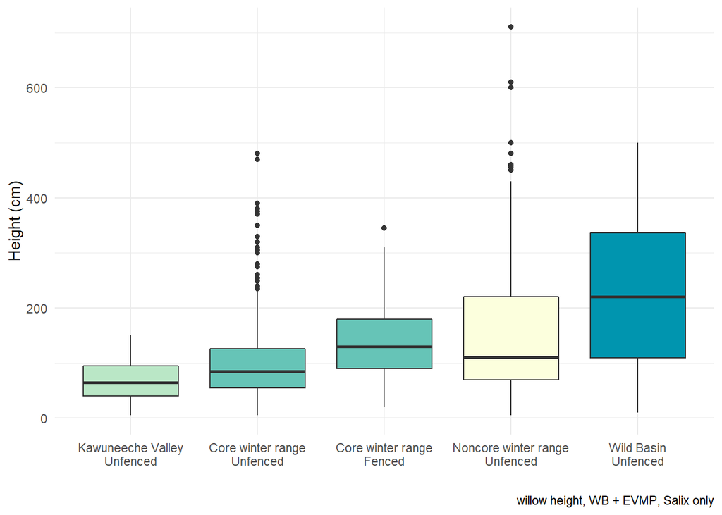

```r
wb.evmp18 %>%
  filter(str_detect(species, "^S")) %>%
  ggplot(aes(x=reorder(site.type.fenced, plant_ht_cm), plant_ht_cm)) +
  geom_boxplot(aes(fill=site_type)) +
  # geom_density(aes(fill = site_type, color = site_type, lty = site_type, x = plant_ht_cm), alpha = 0.05) +
  theme_minimal() +
  scale_fill_manual(values = colfunc2(4)) +
  scale_color_manual(values = colfunc2(4)) +
  theme(legend.position = "none") +
  # theme(axis.text.x = element_text(angle = 35, hjust = 1)) +
  labs(x = "", y  = "Height (cm)", lty= "Site type", color = "Site type", fill = "Site type", caption = "willow height, WB + EVMP, Salix only")
```

```r
ggsave("./output/figures_202107/WB_EVMP_willow_height_boxplot.png", dpi = 300, width = 5.75, height = 4.75)
```

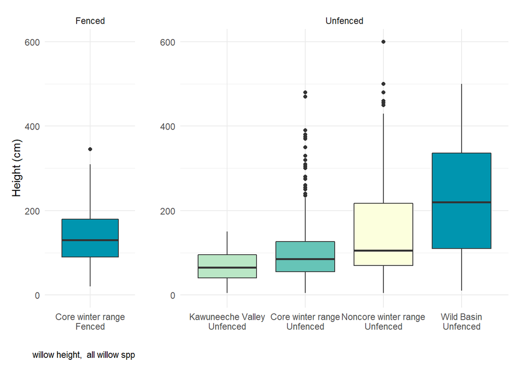

```r
# 2 panel
pl.boxht.wc.f <- wb.evmp18 %>%
  filter(str_detect(species, "^S")) %>%
  filter(site_type == "WC" & fenced == "Fenced") %>%
  ggplot(aes(x=reorder(site.type.fenced, plant_ht_cm), plant_ht_cm)) +
  geom_boxplot(aes(fill=site_type)) +
  # geom_density(aes(fill = site_type, color = site_type, lty = site_type, x = plant_ht_cm), alpha = 0.05) +
  theme_minimal() +
  scale_fill_manual(values = colfunc2(5)) +
  scale_color_manual(values = colfunc2(5)) +
  theme(legend.position = "none") +
  # theme(axis.text.x = element_text(angle = 45, hjust = 1)) +
  labs(x = "", y  = "Height (cm)", lty= "Site type", color = "Site type", fill = "Site type", caption = "willow height,  all willow spp") +
  ylim(0,600) +
  facet_wrap(~fenced, scales = "free_x")

pl.boxht.uf.all <- wb.evmp18 %>%
  filter(str_detect(species, "^S")) %>%
  filter(fenced == "Unfenced") %>%
  ggplot(aes(x=reorder(site.type.fenced, plant_ht_cm), plant_ht_cm)) +
  geom_boxplot(aes(fill=site_type)) +
  # geom_density(aes(fill = site_type, color = site_type, lty = site_type, x = plant_ht_cm), alpha = 0.05) +
  theme_minimal() +
  scale_fill_manual(values = colfunc2(4)) +
  scale_color_manual(values = colfunc2(4)) +
  theme(legend.position = "none") +
  # theme(axis.text.x = element_text(angle = 45, hjust = 1)) +
  labs(x = "", y  = "", lty= "Site type", color = "Site type", fill = "Site type") +
  ylim(0,600) +
  facet_wrap(~fenced, scales = "free_x")


pl.boxht.wc.f + pl.boxht.uf.all + plot_layout(widths = c(.55,2))
```

```r
ggsave("./output/figures_202107/WB_EVMP_willow_height_boxplot2.png", dpi = 300, width = 6.75, height = 4.75)
```

### Modeling and Posterior Description

```r
wb_rt2stan <- wb.evmp18.willows %>%
  select(-yr) %>%
  group_by(site_id,site_type) %>%
  summarytools::descr(stats = "common") %>%
  tb() %>%
  select(c(site_type,mean))

wb_stanaov <- stan_aov(mean ~ site_type, data = wb_rt2stan,
                  prior = R2(location = 0.25), adapt_delta = 0.999,
                  iter = 8000,
                  seed = 12345)
wb_stanaov
```

```
## stan_aov
##  family:       gaussian [identity]
##  formula:      mean ~ site_type
##  observations: 130
##  predictors:   4
## ------
##              Median MAD_SD
## (Intercept)   214.1   16.4
## site_typeWC   -84.9   19.7
## site_typeWK  -143.0   33.2
## site_typeWNC  -16.2   21.9
##
## Auxiliary parameter(s):
##               Median MAD_SD
## R2             0.2    0.1
## log-fit_ratio  0.0    0.1
## sigma         86.7    5.4
##
## ANOVA-like table:
##                   Median  MAD_SD
## Mean Sq site_type 89042.0 29010.3
##
## ------
## * For help interpreting the printed output see ?print.stanreg
## * For info on the priors used see ?prior_summary.stanreg
```

```r
# report::report(wb_stanaov)
```

```r
wb_stanglmer <- stan_lmer(mean ~ 1 + (1|site_type),
                   data = wb_rt2stan, prior_intercept = cauchy(),
                   iter=8000,
                   prior_covariance = decov(shape = 2, scale = 2),
                   adapt_delta = 0.999, seed = 12345)

summary(wb_stanglmer)#
```

```
##
## Model Info:
##  function:     stan_lmer
##  family:       gaussian [identity]
##  formula:      mean ~ 1 + (1 | site_type)
##  algorithm:    sampling
##  sample:       16000 (posterior sample size)
##  priors:       see help('prior_summary')
##  observations: 130
##  groups:       site_type (4)
##
## Estimates:
##                                            mean     sd       10%      50%
## (Intercept)                                  11.8     39.1     -5.1      0.6
## b[(Intercept) site_type:WB]                 202.9     42.6    169.4    211.7
## b[(Intercept) site_type:WC]                 115.7     40.4     89.4    124.9
## b[(Intercept) site_type:WK]                  54.3     46.8      6.7     60.4
## b[(Intercept) site_type:WNC]                186.4     41.9    156.3    195.2
## sigma                                        87.3      5.5     80.4     87.0
## Sigma[site_type:(Intercept),(Intercept)]  56309.2  61804.0  13914.1  37753.1
##                                            90%
## (Intercept)                                  35.3
## b[(Intercept) site_type:WB]                 236.3
## b[(Intercept) site_type:WC]                 142.7
## b[(Intercept) site_type:WK]                 101.6
## b[(Intercept) site_type:WNC]                218.2
## sigma                                        94.5
## Sigma[site_type:(Intercept),(Intercept)] 117135.8
##
## Fit Diagnostics:
##            mean   sd    10%   50%   90%
## mean_PPD 158.7   10.9 144.8 158.5 172.6
##
## The mean_ppd is the sample average posterior predictive distribution of the outcome variable (for details see help('summary.stanreg')).
##
## MCMC diagnostics
##                                          mcse   Rhat   n_eff
## (Intercept)                                 1.4    1.0   760
## b[(Intercept) site_type:WB]                 1.4    1.0   873
## b[(Intercept) site_type:WC]                 1.4    1.0   825
## b[(Intercept) site_type:WK]                 1.4    1.0  1177
## b[(Intercept) site_type:WNC]                1.4    1.0   859
## sigma                                       0.1    1.0  7279
## Sigma[site_type:(Intercept),(Intercept)] 1158.7    1.0  2845
## mean_PPD                                    0.1    1.0 16701
## log-posterior                               0.1    1.0  1048
##
## For each parameter, mcse is Monte Carlo standard error, n_eff is a crude measure of effective sample size, and Rhat is the potential scale reduction factor on split chains (at convergence Rhat=1).
```

```r
describe_posterior(
  wb_stanglmer,
  effects = "all",
  component = "all",
  test = c("p_direction", "p_significance"),
  centrality = "all"
) %>%
  gt()
```

| Parameter | Effects | Component | Median | Mean | MAP | CI | CI_low | CI_high | pd | ps | Rhat | ESS |
| --- | --- | --- | --- | --- | --- | --- | --- | --- | --- | --- | --- | --- |
| (Intercept) | fixed | conditional | 6.474931e-01 | 11.76255 | -6.225121e-03 | 0.95 | -28.35513 | 118.91765 | 0.5757500 | 0.1733125 | 1.004323 | 759.9500 |
| b[(Intercept) site_type:WB] | random | conditional | 2.116868e+02 | 202.92684 | 2.132987e+02 | 0.95 | 94.91439 | 260.35942 | 0.9959375 | 0.9943125 | 1.003650 | 872.5293 |
| b[(Intercept) site_type:WC] | random | conditional | 1.249110e+02 | 115.65689 | 1.258237e+02 | 0.95 | 10.18839 | 165.68727 | 0.9643125 | 0.9571875 | 1.004226 | 824.7230 |
| b[(Intercept) site_type:WK] | random | conditional | 6.043394e+01 | 54.28535 | 6.462747e+01 | 0.95 | -48.29569 | 137.09116 | 0.9135000 | 0.8911250 | 1.002778 | 1176.6734 |
| b[(Intercept) site_type:WNC] | random | conditional | 1.952310e+02 | 186.42151 | 1.994495e+02 | 0.95 | 76.97108 | 240.74741 | 0.9933125 | 0.9912500 | 1.004171 | 859.4127 |
| Sigma[site_type:(Intercept),(Intercept)] | random | conditional | 3.775306e+04 | 56309.22616 | 2.521362e+04 | 0.95 | 858.97442 | 161849.86698 | 1.0000000 | 1.0000000 | 1.000574 | 2845.2345 |
| sigma | fixed | sigma | 8.698569e+01 | 87.26022 | 8.631719e+01 | 0.95 | 76.70337 | 97.97795 | 1.0000000 | 1.0000000 | NA | NA |

# Session info

R version 4.0.3 (2020-10-10)  
Platform: x86_64-w64-mingw32/x64 (64-bit)  
Running under: Windows 10 x64 (build 19041)  
Run date: 2021 August 13

Package Information

| Package | Version | Reference |
| --- | --- | --- |
| bayesplot | 1.8.1 | Gabry J, Mahr T (2021). "bayesplot: Plotting for Bayesian Models." Rpackage version 1.8.1, <URL: https://mc-stan.org/bayesplot/>. |
| bayestestR | 0.10.5 | Makowski, D., Ben-Shachar, M., & Lüdecke, D. (2019). bayestestR: Describing Effects and their Uncertainty, Existence and Significance within the Bayesian Framework. Journal of Open Source Software, 4(… |
| dplyr | 1.0.7 | Hadley Wickham, Romain François, Lionel Henry and Kirill Müller (2021). dplyr: A Grammar of Data Manipulation. R package version 1.0.7. https://CRAN.R-project.org/package=dplyr |
| DT | 0.18 | Yihui Xie, Joe Cheng and Xianying Tan (2021). DT: A Wrapper of the JavaScript Library 'DataTables'. R package version 0.18. https://CRAN.R-project.org/package=DT |
| emmeans | 1.6.2.1 | Russell V. Lenth (2021). emmeans: Estimated Marginal Means, aka Least-Squares Means. R package version 1.6.2-1. https://CRAN.R-project.org/package=emmeans |
| forcats | 0.5.1 | Hadley Wickham (2021). forcats: Tools for Working with Categorical Variables (Factors). R package version 0.5.1. https://CRAN.R-project.org/package=forcats |
| ggplot2 | 3.3.5 | H. Wickham. ggplot2: Elegant Graphics for Data Analysis. Springer-Verlag New York, 2016. |
| ggridges | 0.5.3 | Claus O. Wilke (2021). ggridges: Ridgeline Plots in 'ggplot2'. R package version 0.5.3. https://CRAN.R-project.org/package=ggridges |
| gt | 0.3.1 | Richard Iannone, Joe Cheng and Barret Schloerke (2021). gt: Easily Create Presentation-Ready Display Tables. R package version 0.3.1. https://CRAN.R-project.org/package=gt |
| janitor | 2.1.0 | Sam Firke (2021). janitor: Simple Tools for Examining and Cleaning Dirty Data. R package version 2.1.0. https://CRAN.R-project.org/package=janitor |
| knitr | 1.33 | Yihui Xie (2021). knitr: A General-Purpose Package for Dynamic Report Generation in R. R package version 1.33. |
| lubridate | 1.7.10 | Garrett Grolemund, Hadley Wickham (2011). Dates and Times Made Easy with lubridate. Journal of Statistical Software, 40(3), 1-25. URL https://www.jstatsoft.org/v40/i03/. |
| patchwork | 1.1.1 | Thomas Lin Pedersen (2020). patchwork: The Composer of Plots. R package version 1.1.1. https://CRAN.R-project.org/package=patchwork |
| purrr | 0.3.4 | Lionel Henry and Hadley Wickham (2020). purrr: Functional Programming Tools. R package version 0.3.4. https://CRAN.R-project.org/package=purrr |
| R | 4.0.3 | R Core Team (2020). R: A language and environment for statistical computing. R Foundation for Statistical Computing, Vienna, Austria. URL https://www.R-project.org/. |
| Rcpp | 1.0.7 | Dirk Eddelbuettel and Romain Francois (2011). Rcpp: Seamless R and C++ Integration. Journal of Statistical Software, 40(8), 1-18. URL https://www.jstatsoft.org/v40/i08/. |
| readr | 2.0.1 | Hadley Wickham and Jim Hester (2021). readr: Read Rectangular Text Data. R package version 2.0.1. https://CRAN.R-project.org/package=readr |
| rstanarm | 2.21.1 | Goodrich B, Gabry J, Ali I & Brilleman S. (2020). rstanarm: Bayesian applied regression modeling via Stan. R package version 2.21.1 https://mc-stan.org/rstanarm. |
| stringr | 1.4.0 | Hadley Wickham (2019). stringr: Simple, Consistent Wrappers for Common String Operations. R package version 1.4.0. https://CRAN.R-project.org/package=stringr |
| summarytools | 1.0.0 | Dominic Comtois (2021). summarytools: Tools to Quickly and Neatly Summarize Data. R package version 1.0.0. https://CRAN.R-project.org/package=summarytools |
| tibble | 3.1.3 | Kirill Müller and Hadley Wickham (2021). tibble: Simple Data Frames. R package version 3.1.3. https://CRAN.R-project.org/package=tibble |
| tidyr | 1.1.3 | Hadley Wickham (2021). tidyr: Tidy Messy Data. R package version 1.1.3. https://CRAN.R-project.org/package=tidyr |
| tidyverse | 1.3.1 | Wickham et al., (2019). Welcome to the tidyverse. Journal of Open Source Software, 4(43), 1686, https://doi.org/10.21105/joss.01686 |
| viridis | 0.6.1 | Simon Garnier, Noam Ross, Robert Rudis, Antônio P. Camargo, Marco Sciaini, and Cédric Scherer (2021). Rvision - Colorblind-Friendly Color Maps for R. R package version 0.6.1. |
| viridisLite | 0.4.0 | Simon Garnier, Noam Ross, Robert Rudis, Antônio P. Camargo, Marco Sciaini, and Cédric Scherer (2021). Rvision - Colorblind-Friendly Color Maps for R. R package version 0.4.0. |

# References

Brilleman, SL, MJ Crowther, M Moreno-Betancur, J Buros Novik, and R Wolfe. 2018. “StatCon 2018. 10-12 Jan 2018.” In. Pacific Grove, CA, USA. https://github.com/stan-dev/stancon_talks/.

Gabry, Jonah, Daniel Simpson, Aki Vehtari, Michael Betancourt, and Andrew Gelman. 2019. “Visualization in Bayesian Workflow.” *Journal of the Royal Statistical Society: Series A (Statistics in Society)* 182 (2): 389–402. https://doi.org/10.1111/rssa.12378.

Goodrich, B, J Gabry, I Ali, and S Brilleman. 2020. “Rstanarm: Bayesian Applied Regression Modeling via Stan. R Package Version 2.19.3 Https://Mc-Stan.org/Rstanarm.”

Wickham, Hadley, Mara Averick, Jennifer Bryan, Winston Chang, Lucy D’Agostino McGowan, Romain François, Garrett Grolemund, Alex Hayes, Lionel Henry, and Jim Hester. 2019. “Welcome to the Tidyverse.” *Journal of Open Source Software* 4 (43): 1686.

Zeigenfuss, Linda C., and Therese L. Johnson. 2015. “Monitoring of Vegetation Response to Elk Population and Habitat Management in Rocky Mountain National Park, 200814.” Reston, VA. https://doi.org/10.3133/ofr20151216.

Zeigenfuss, Linda C, Therese L Johnson, and Zachary Wiebe. 2011. “Monitoring Plan for Vegetation Responses to Elk Management in Rocky Mountain National Park.”